# Analysis - Data Exploration Proj

Valentina Bernal

2023-05-10

```r
# Importing the clean data
data2 <- import('clean_scorecard_data1.xlsx')
```

Research Question: Among colleges that predominantly grant bachelor’s degrees, did the release of the scorecard shift student interest to high-earnings colleges relative to low-earnings ones? - proxied by Google searches for keywords associated with those colleges?

# Exploring the data

```r
# Exploring the data
# Average index for the years prior to the release of the scorecard

avg_index <- data2 %>%
  select(schname, monthorweek, agg_index) %>%
  group_by(schname) %>%
  mutate(monthorweek = str_sub(monthorweek, 1, 4)) %>%
  mutate(avgindex = mean(agg_index))

# View in descending order
avg_index <- avg_index[order(avg_index$avgindex, decreasing = TRUE),]
```

```r
# Average index for just the year 2014 (prior to scorecard release year)
avg_index14 <- avg_index %>%
  filter(monthorweek == 2014)
```

```r
# Average index for just the year 2015 (scorecard release year)
avg_index15 <- avg_index %>%
  filter(monthorweek == 2015)
```

# Looking at time trends that could possibly be affecting the index changes

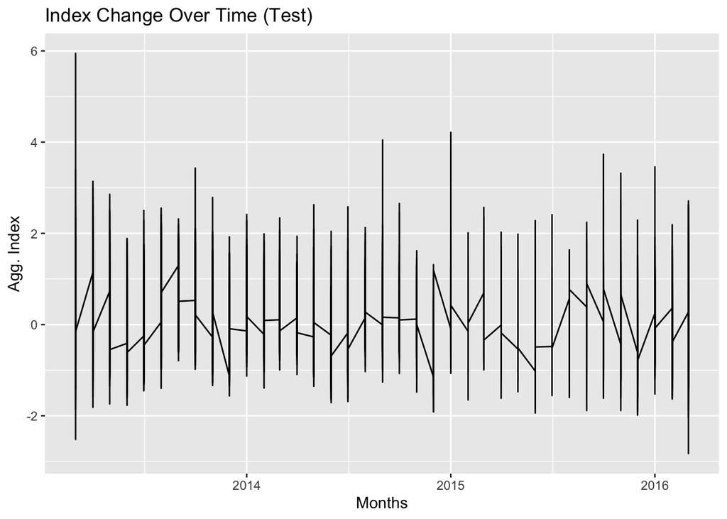

```r
ggplot(data = data2, aes(x = monthorweek, y = agg_index)) +
  geom_line() +
  labs(title = "Index Change Over Time (Test)", x = "Months", y = "Agg. Index")
```

```r
# Covariance
data2 <- rename(data2, median_earnings = 'md_earn_wne_p10-reported-earnings') %>%
  filter(median_earnings != 'PrivacySuppressed')
```

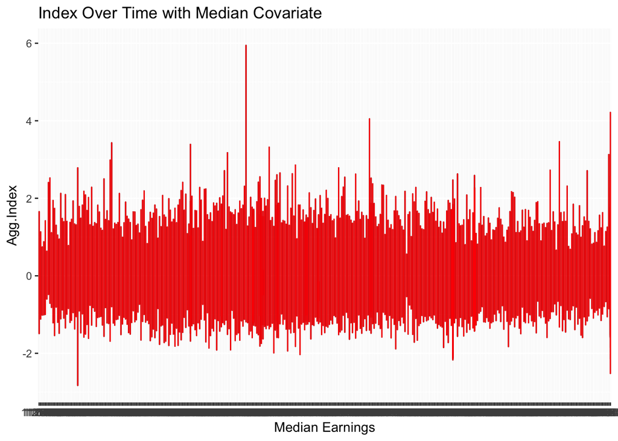

```r
ggplot(data = data2, aes(x = median_earnings, y = agg_index)) +
  geom_line() +
  geom_line(aes(y = agg_index), color = "red") +
  labs(title = "Index Over Time with Median Covariate", x = "Median Earnings", y = "Agg.Index")
```

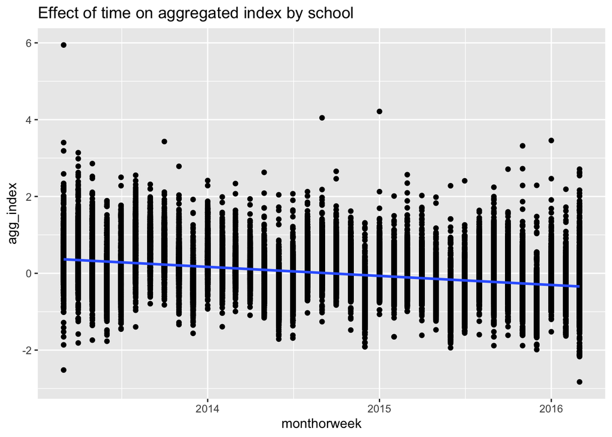

```r
# How can I graphically determine whether index fluctuation differs across different universities following the release of the scorecard? - thus indicating causality between scorecard results and interest in high earnings universities

ggplot(data2, aes(x = monthorweek, y = agg_index)) +
  geom_point() +
  #facet_wrap(~ schname) +
  geom_smooth(method = "lm", se = FALSE) +
  labs(title = "Effect of time on aggregated index by school")
```

According to data from the National Center for Education Statistics (NCES), the average salary earnings for college graduates in the U.S. in 2015 varied depending on their field of study: Business: 50,000 - 60,000 per year Engineering: 60,000 - 70,000 per year Computer Science: 60,000 - 70,000 per year Social Sciences: 40,000 - 50,000 per year Humanities: 30,000 - 40,000 per year

```r
vars <- data2 %>%
  mutate(earnings  = case_when(
    median_earnings <= 25000 ~ 'Low Earning',
    median_earnings >= 75000 ~ 'High Earning',
    TRUE ~ 'Medium Earning'
  ))

# Remove NA
vars <- vars %>%
  filter(!is.na(earnings))

#feols(log(median_earnings) ~ agg_index + I(earnings > 0), data = vars) |> etable()
```

```r
# Just looking at high/low earning
vars <- vars %>% filter(earnings != 'Medium Earning')
```

```r
# Can we compare before or after the release of the scorecard?
vars <- vars %>%
  mutate(Before_After_SC = case_when(
    monthorweek <= '2015-09-01' ~ 'Before',
    monthorweek > '2015-09-01' ~ 'After'))
```

```r
# Take only relevant columns
vars2 <- vars %>%
  select(schname, monthorweek, agg_index, median_earnings, earnings, Before_After_SC) %>%
  filter(!is.na(earnings))
```

```r
# What are the average indexes for the scorecard time period (before/after) relative to earnings level?

index_vs_time <- vars2 %>%
  group_by(earnings, Before_After_SC, monthorweek) %>%
  summarize(summary_index = mean(agg_index))
index_vs_time$monthorweek <- as.Date(index_vs_time$monthorweek)
```

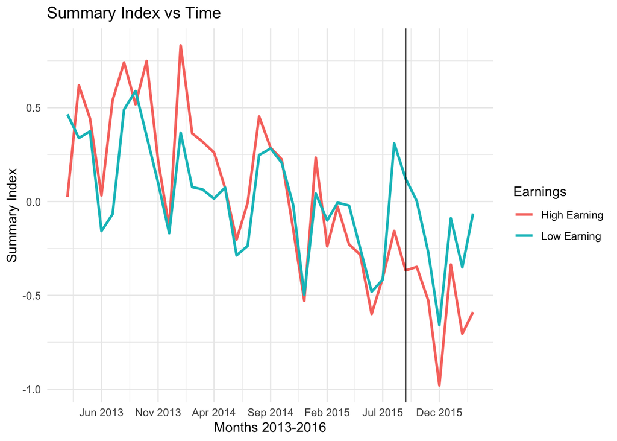

```r
# Visual representation

index_vs_time2 <- ggplot(data = index_vs_time, aes(x = monthorweek, y = summary_index, color = earnings)) +
  geom_line(size = 1) +
  geom_vline(xintercept = ymd('2015-09-01')) + theme_minimal() +
  scale_x_date(date_breaks = "5 month", date_labels = "%b %Y") +
  labs(title = "Summary Index vs Time",
       x = "Months 2013-2016",
       y = "Summary Index",
       color = "Earnings")
index_vs_time2
```

Here I can more easily look at the aggregated indexes over the monthly periods with each line displaying high and low earnings universities with their changing index numbers. The intercept shown is the date that the scorecard was released on.

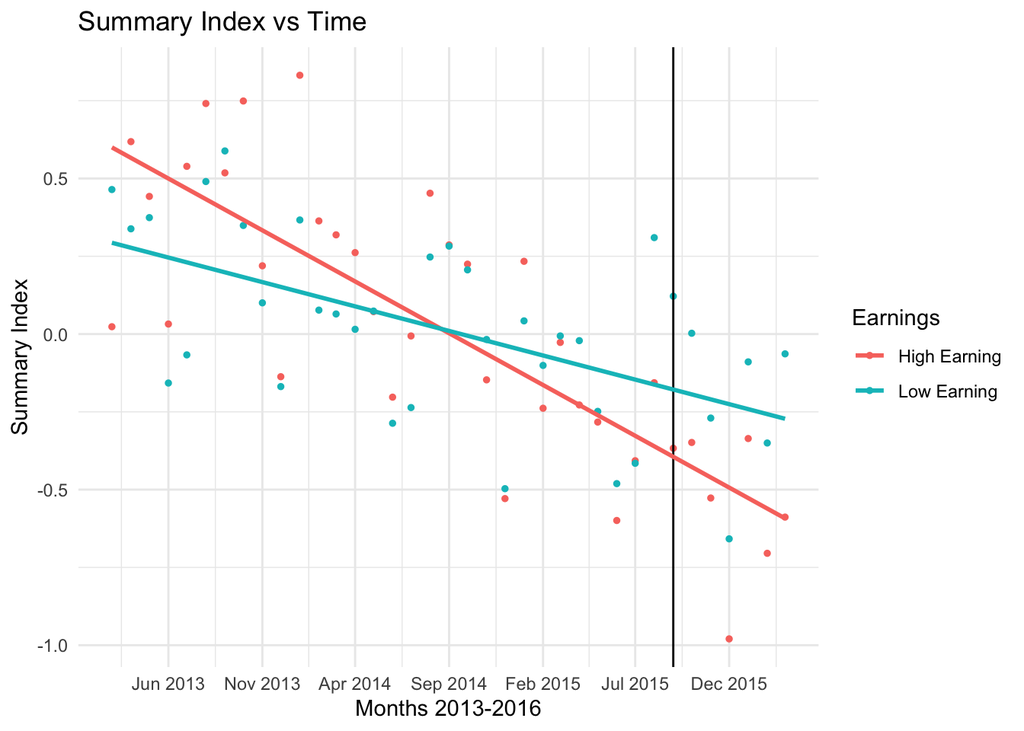

```r
# A different view

ggplot(data = index_vs_time, aes(x = monthorweek, y = summary_index, color = earnings)) +
  geom_point(size = 1) +
  geom_vline(xintercept = ymd('2015-09-01')) + theme_minimal() +
  geom_smooth(method = "lm", se = FALSE) +
  scale_x_date(date_breaks = "5 month", date_labels = "%b %Y") +
  labs(title = "Summary Index vs Time",
       x = "Months 2013-2016",
       y = "Summary Index",
       color = "Earnings")
```

This is an additional view in scatterplot form that also includes a line of best fit that provides a view for what the index trend might continue looking like.

Regression

```r
# Is there a causal relationship between the release of the scorecard and its effect on interest shift from high and low earnings universities?
```

```r
# Binary variable test
test <- index_vs_time %>%
  mutate(high_earnings = ifelse(earnings == "High Earning", 1, 0), low_earnings = ifelse(earnings== "Low Earning", 1, 0)) %>%
  mutate(scorecard_release = ifelse(monthorweek < '2015-09-01', 0, 1))
```

```r
model_test2 <- feols(summary_index ~ high_earnings:scorecard_release + low_earnings:scorecard_release + monthorweek, data = test)
etable(model_test2)
```

```
##                                           model_test2
## Dependent Var.:                         summary_index
##
## Constant                             12.83*** (2.098)
## monthorweek                       -0.0008*** (0.0001)
## high_earnings x scorecard_release    -0.2019 (0.1287)
## scorecard_release x low_earnings      0.1615 (0.1287)
## _________________________________ ___________________
## S.E. type                                         IID
## Observations                                       74
## R2                                            0.52653
## Adj. R2                                       0.50624
## ---
## Signif. codes: 0 '***' 0.001 '**' 0.01 '*' 0.05 '.' 0.1 ' ' 1
```

## Results Write Up

My regression output shows the results of a linear regression model with “summary_index” as the dependent variable. This variable is the result of the standardized index average relative to schools, the scorecard release period (before/after), and the earnings level (high/low). I am also controlling for the time period (monthorweek) keeping in mind that interest may shift due to economic fluctuations.

The interaction term I included between “high_earnings” and “scorecard_release” has a negative coefficient of -0.2019, but it is not statistically significant which indicates that we can’t confirm a significant causal relationship in the effect of the Scorecard release on the interest of students in high-earning colleges compared to low-earning ones. The second interaction between “scorecard_release” and “low_earnings” has a positive coefficient of 0.1615, but it is also not statistically significant because of the p-value > 0.05. This also indicates that there is not enough evidence to confirm a significant difference in the effect of the Scorecard release on the interest of students in low-earning colleges compared to high-earning ones. The model’s R-squared is demonstrating that 52.65% of the variance in the indexes is explained by the independent variables (earnings*scorecard release interactions) showed by the model.

In conclusion, the results from my regression model and analysis overall are exhibiting no significant difference in the effect of the Scorecard release on the interest of students in high-earning colleges compared to low-earning ones, based on the index level. Something to keep in mind with these results is the limited time frame of data following the release of the scorecard, and perhaps considering that more data would likely alter the index results over a longer period of time.